# Git Crash Course

# Presenter Notes

# Git is...

- a collection of commits that represent code changes
- distributed (redundant)
- flexibile
- network optional

# Presenter Notes

# can be a little intimidating

[figure not shown]

# Presenter Notes

# a commit is...

- snapshot, not a diff
- referred to by a checksum (not a name)
- takes up more space, but bits are cheap
- store links to files that haven't changed

# Presenter Notes

# stop worrying

- Git (generally) only adds data
- it's hard to lose things once committed
- almost always possible to roll back changes
- other than 'fetch', 'push', and 'pull', nearly everything is local

# Presenter Notes

# three (or four) stages of Git

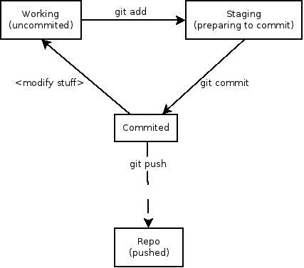

# Presenter Notes

# basic workflow

### make some changes

### stage snapshots of files

### commit

### (eventually) push

# Presenter Notes

# a commit has...

- a checksum
- all blobs contained in the commit
- a comment (please use these)

Format your commit like:

```
80 character summary

longer description of
changes, maybe include a bulleted
list of changes you made
```

# Presenter Notes

# getting set up

```
git config --global user.name "Your Name"
git config --global user.email "you@your.site"
```

# Presenter Notes

# status report

```
$ git status
 # Initial commit
 #
 # Changes to be committed:
 #   (use "git rm --cached <file>..." to unstage)
 #
 #       new file:   README
$ vim README
$ git status
 # Initial commit
 #
 # Changes to be committed:
 #   (use "git rm --cached <file>..." to unstage)
 #
 #       new file:   README
 #
 # Changes not staged for commit:
 #   (use "git add <file>..." to update what will
 #   be committed)
 #   (use "git checkout -- <file>..." to discard
 #   changes in working directory)
 #
 #       modified:   README
```

# Presenter Notes

# making commitments

```
$ git commit -m "Added README"
[master (root-commit) 4f3ea33] Added README
 1 files changed, 1 insertions(+), 0 deletions(-)
 create mode 100644 README
 <Do more commits>
$ git log --oneline
 773c310 added hello.py
 7275078 More verbosity for the README
 4f3ea33 Added README
```

Protips:

```
# set commit message without opening an editor
git commit -m 'commit message'
# add only parts of what was changed
git add -p
```

# Presenter Notes

# see what changed

- use 'git diff'
- by default diffs current working dir with most recent commit
- super useful, check out 'git diff --help'

# Presenter Notes

```
$ vim hello.py
$ git diff
 diff --git a/hello.py b/hello.py
 index 3148dce..33f348b 100644
 --- a/hello.py
 +++ b/hello.py
 @@ -1,3 +1,3 @@
  #!/usr/bin/env python

 -print "hello world"
 +print "Hello, world!"
$ git commit -am "Fixed up grammar in hello.py"
[master 01ee7f3] Fixed up grammar in hello.py
 1 files changed, 1 insertions(+), 1 deletions(-)
```

# Presenter Notes

# check it out

```
$ git log --oneline --decorate
    1c8ce74 (HEAD, origin/newgitseminar, newgitseminar) Added more on branching
    4afbe50 Added slides for branching
    151dd2f Finished converting to vanilla markdown
    5e130da Added git seminar to front page
    d219f44 New Git seminar via Landslide now working
    dfbc19c (origin/master, origin/HEAD, master) Changed length of excerpt

    # specify a branch that is on the remote named 'origin'
$ git checkout origin/master
    # specify a branch name
$ git checkout master
    # specify commit ID (or hash)
$ git dfbc19c
    # specify a commit that is 5 commits prior to where HEAD is
$ git checkout HEAD~5
```

All those checkouts go to the same commit

# check out a specific file

```
    # get the older version of file 'filename'
$ git checkout -- filename
    # throw away all local changes and switch to branch 'master'
$ git checkout -f master
```

# Presenter Notes

# branching

# Presenter Notes

# branching

- lightweight (creating a branch requires 40 bytes of space)
- pointers to different commits
- conveneint ways to separate tasks and features

# Presenter Notes

# feature branches

- use master and develop branches
- merge features to develop, then to master
- merge hotfixes directly to master as needed

# Presenter Notes

# starting with branches

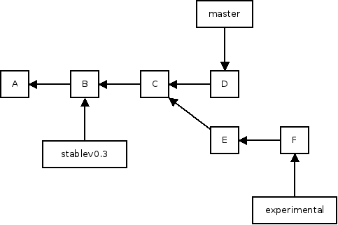

get a branch

```
$ git checkout branchname
```

create a new branch with name branchname

```
$ git checkout -b branchname
#or
git branch branchname
git checkout branchname
```

# Presenter Notes

# develop asynchronously

```
*   5a376b1 - Merge branch 'master' of github.com:boto/boto
|\
| * 2f03097 - Adding ref/dynamodb to hidden TOC.
| *   649bad2 - Merging in @rdodev's DynamoDB tutorial and adapting it for Layer2
| |\
| | * d5defb8 - Little changes
| | * 0a5046c - Starting point. We can add more details later on.
| | * a99fb2e - Grammar fix
| | * d5d3edb - Minor redaction edits
| | *   e5a397f - Merge branch 'master' of git@github.com:rdodev/boto.git
| | |\
| | | * 8c19b40 - Fixing code example
| | * | f35a84d - Added subsections
```

# merge branches whenever

# Presenter Notes

# working with branches

push one of your branches up to a remote

```
$ git push origin testfeature:experimental
```

to display all local branches

```
$ git branch
      master
    * develop
      feature/newMenuBar
      hotfix/MVP-449
```

# Presenter Notes

# bring it back together

```
git checkout master
git merge experiment
< resolve conflicts >

Hello
<<<<<<< HEAD
there
=======
experimental
>>>>>>> experiment
world

git commit -m "Merged in my experimental feature"
```

# Presenter Notes

# workflows

# Presenter Notes

# workflows

- git-flow: we'll get there in a second
- github-style: a unique take on git-flow, with continuous integration in mind
- integration manager: one 'integration manager' is the only person with commit access to a 'blessed' repo
- dictator + lieutenants: great for massive projects (cough-linuxkernel-cough) where people are given responsibility for a subsystem ('lieutenants') and passes merged changes to the dictator to be finally commited

# Presenter Notes

# git-flow

my personal favorite

# Presenter Notes

# git is flexible mix and match workflows

# Presenter Notes

# Cheat Sheet

```
# unstage a file
$ git reset HEAD <filename>...
# undo the changes to a file
$ git checkout -- <filename>
# delete a file from your staging area, but not working directory
$ git rm --cached <filename>
# view all unstaged changes
$ git diff
# view all staged changes
$ git diff --cached
# add a file to your last commit
$ git commit -m "A commit"
$ git add file_i_forgot.txt
$ git commit --amend
# see the last 5 days of activity on the repository, concisely
$ git log --since=5.days --oneline
```

# Presenter Notes

# github.com

[figure not shown]

# Presenter Notes

# find a project

[figure not shown]

# Presenter Notes

# 800,000 original projects

```
>> Repository.count(:conditions =>
    { :parent_id => nil, :public => 1 })
=> 805411
```

# Presenter Notes

# be part of a community

# Presenter Notes

# contribute back

- fork
- commit
- push
- (pull request)

# Presenter Notes

# get the code

```
$ git clone git://github.com/some1/project
Cloning into project...
$ cd project/
$ vim README
$ git commit -am 'made it better'
[master dbeb245] made it better
 1 files changed, 2 insertions(+), 0 deletions(-)
$ (fork it on github)
$ git remote add myfork git@github.com:you/project.git
$ git push myfork master:feature_name
...
To git@github.com:you/project.git
   9457e38..dbeb245  master -> feature_name
```

improve someone else's repo, in just one minute

# Presenter Notes

# ???

# Presenter Notes

# resources

- gitready.com
- gitref.org
- progit.org
- git-scm.com
- [Git Cheat Sheet](http://cheat.errtheblog.com/s/git)

# Presenter Notes

# Ryan Brown

# Programmer, Git User

### ryansb@csh.rit.edu

### github.com/ryansb

### gplus.to/ryansb

# Presenter Notes